# InVivoStat Single Measure Parametric Analysis

## Response and covariate

The Resp14 response is currently being analysed by the Single Measures Parametric Analysis module, with Cov7 fitted as a covariate.

## Scatterplot of the observed data

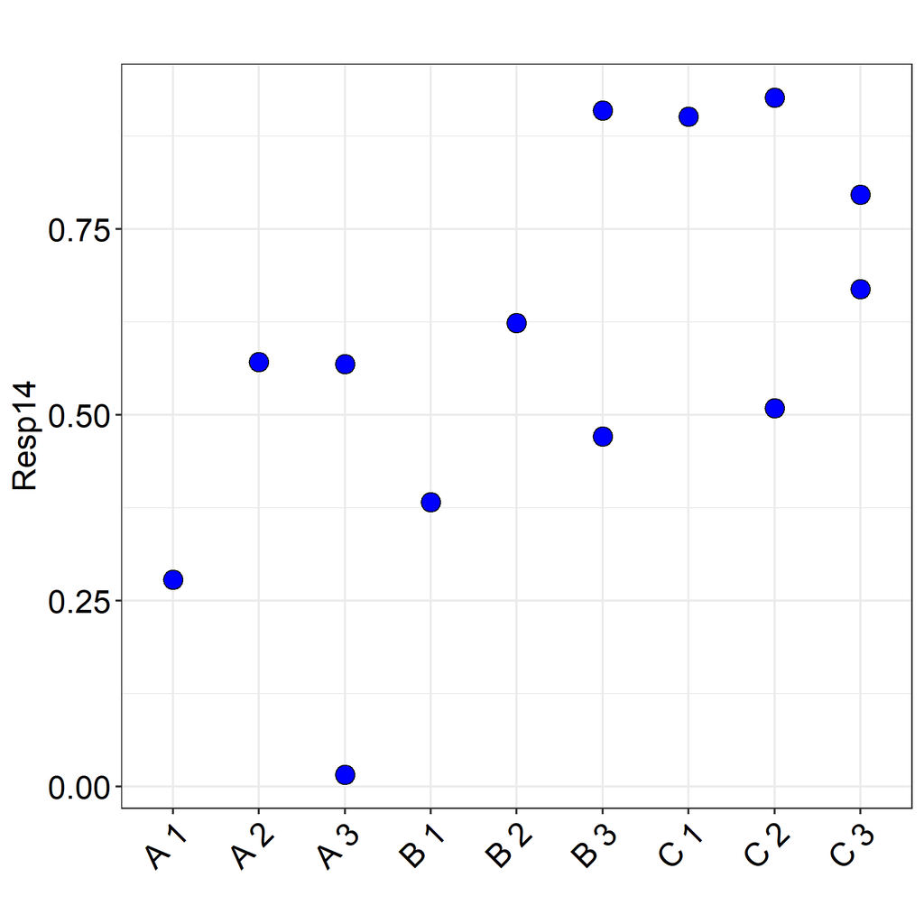

Tip: Use this plot to identify possible outliers.

## Plot of the response vs. the covariate, categorised by the primary factor

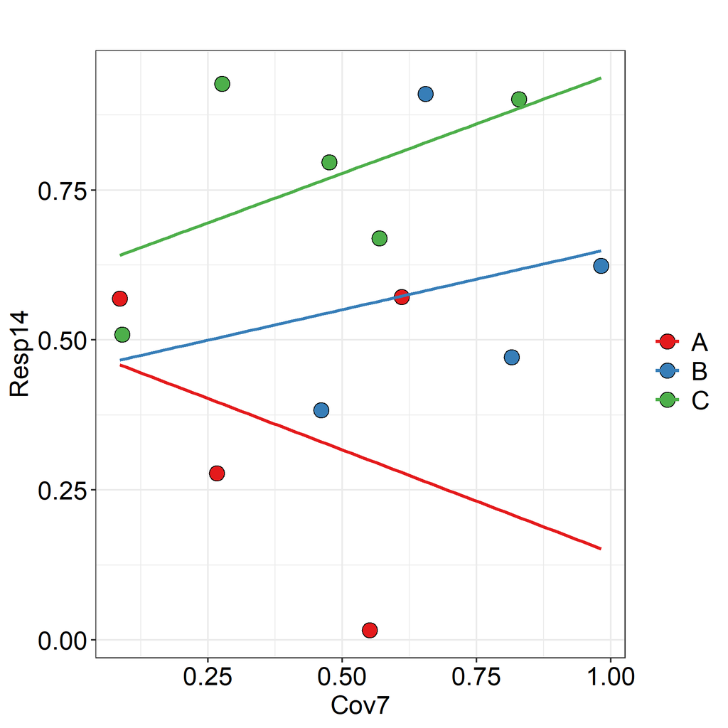

Tip: In order to decide whether it is helpful to fit the covariate, the following should be considered:

a) Is there a relationship between the response and the covariate? (N.B., It is only worth fitting the covariate if there is a strong positive (or negative) relationship between them: i.e., the lines on the plot should not be horizontal).

b) Is the relationship similar for all treatments? (The lines on the plot should be approximately parallel).

c) Is the covariate influenced by the treatment? (We assume the covariate is not influenced by the treatment and so there should be no separation of the treatment groups along the x-axis on the plot).

## Analysis of Covariance (ANCOVA) table for assessing covariate interactions

The covariate interactions have not been calculated as there are zero residual degrees of freedom when all terms are included in the statistical model.

The Residual Sums of Squares is close to zero indicating the model is overfitted (too many terms are included in the model). Either the model should be simplified, to reduce the number of terms in the model, or the output option to test covariate interactions should be deselected.